# Lab 5: Baby Names

Reesa John

February 20, 2019

# Introduction

In this report, I am going to examine the trends in the names Brandon and Jennifer over time. I have chosen to do an analysis on these names as they are the names of two of my close friends.

# The Data

The data used in this report comes from the data set “babies_ca.xlsx” which contains information about baby names in California from 1940-2016. For each year, and for each name with at least 50 recorded babies born overall, we are given the counts of how many babies had that name of each gender.

Before creating any statistical models, I have first decided to see if there are any male Jennifers or female Brandons. Jennifer is a name commonly associated with girls and Brandon is a name commonly associated with boys. If there are any of the other gender, I would need to take that into consideration.

```
## # A tibble: 6 x 5
##   State Gender  Year Name    Count
##   <chr> <chr>  <dbl> <chr>   <dbl>
## 1 CA    F       1970 Brandon     6
## 2 CA    F       1971 Brandon     6
## 3 CA    F       1973 Brandon     7
## 4 CA    F       1974 Brandon     5
## 5 CA    F       1975 Brandon    14
## 6 CA    F       1976 Brandon     5
```

```
## # A tibble: 6 x 5
##   State Gender  Year Name     Count
##   <chr> <chr>  <dbl> <chr>    <dbl>
## 1 CA    M       1954 Jennifer     5
## 2 CA    M       1961 Jennifer     8
## 3 CA    M       1965 Jennifer     5
## 4 CA    M       1967 Jennifer     5
## 5 CA    M       1969 Jennifer     9
## 6 CA    M       1970 Jennifer    11
```

The results show that there do indeed exist male Jennifers and female Brandons born in California. As such, I have decided to create two linear models, for each name, one for the males, and the other for the females.

# Jennifer

```
##
## Call:
## lm(formula = Count ~ Year * Gender, data = jennifers)
##
## Residuals:
##     Min      1Q  Median      3Q     Max
## -2671.8 -1301.0    -4.8   109.9  3875.8
##
## Coefficients:
##                Estimate Std. Error t value Pr(>|t|)
## (Intercept)  -29970.582  16980.435  -1.765   0.0803 .
## Year             16.309      8.582   1.900   0.0600 .
## GenderM       29638.468  47472.464   0.624   0.5337
## Year:GenderM    -16.133     23.946  -0.674   0.5019
## ---
## Signif. codes:  0 '***' 0.001 '**' 0.01 '*' 0.05 '.' 0.1 ' ' 1
##
## Residual standard error: 1641 on 110 degrees of freedom
## Multiple R-squared:  0.3229, Adjusted R-squared:  0.3045
## F-statistic: 17.49 on 3 and 110 DF,  p-value: 2.359e-09
```

Looking at the results for the linear model, we see that the number of female Jennifers in California throughout the years have gone up with time, as the slope is 16.309. For males, the slope is nearly 0, at approximately 0.2. That said, it is still slightly positive.

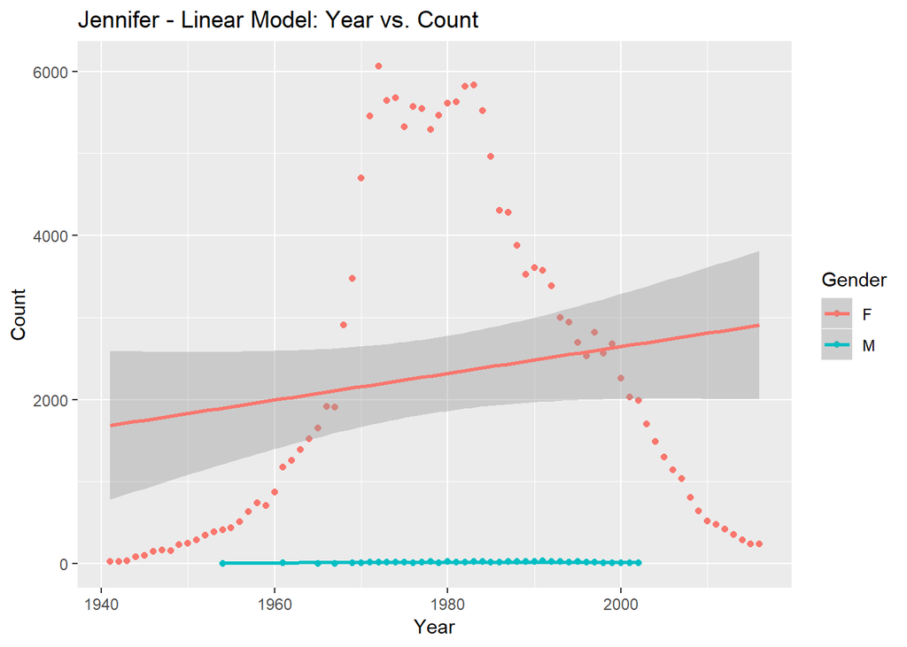

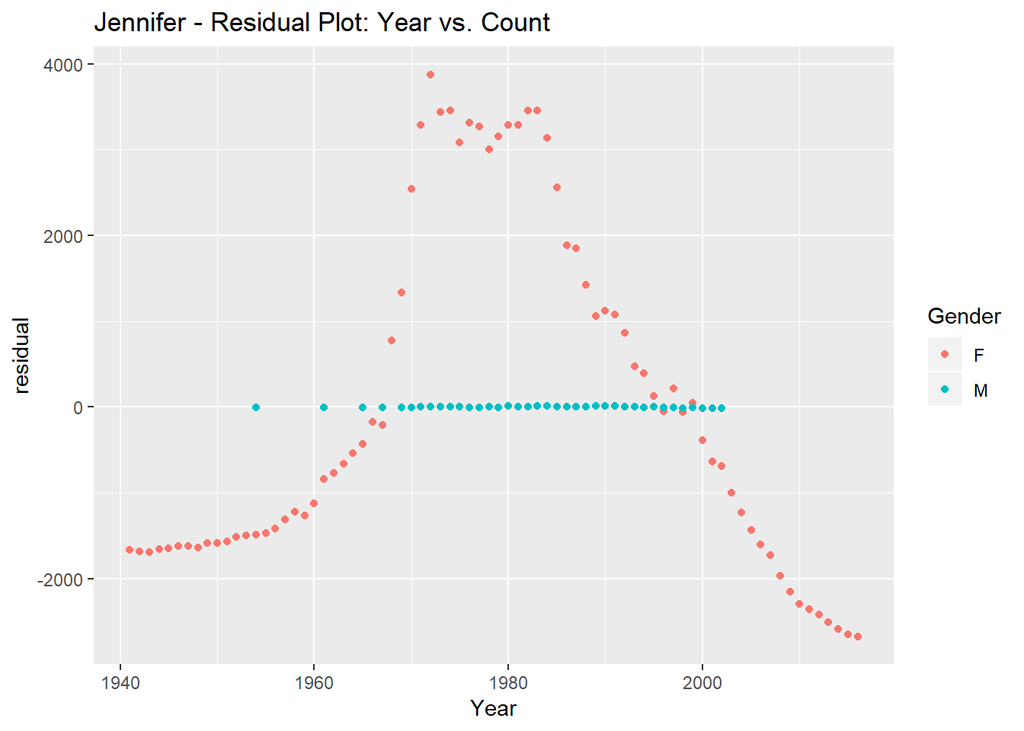

Looking at the linear models against the scatterplots for female and male baby Jennifers across time in California, and their respective residual plots, its obvious at once that the linear model is an awful fit for female Jennifer’s accross time.

It increased rapidly in popularity from 1940 to 1970, and remained extremely popular from 1970 to 1983, but post 1983, it experienced a rapid decrease in popularity that continued until the last year of this data set, 2016

And while the linear model is an excellent fit for the male Jennifers, as their residuals are all very close to 0, their counts are very low.

# Brandon

```
##
## Call:
## lm(formula = Count ~ Year * Gender, data = brandons)
##
## Residuals:
##      Min       1Q   Median       3Q      Max
## -1874.48  -271.96    -5.02    55.38  1568.93
##
## Coefficients:
##                Estimate Std. Error t value Pr(>|t|)
## (Intercept)   5.719e+00  2.181e+04   0.000 0.999791
## Year          3.039e-03  1.098e+01   0.000 0.999780
## GenderM      -7.706e+04  2.305e+04  -3.343 0.001174 **
## Year:GenderM  3.952e+01  1.160e+01   3.406 0.000958 ***
## ---
## Signif. codes:  0 '***' 0.001 '**' 0.01 '*' 0.05 '.' 0.1 ' ' 1
##
## Residual standard error: 621.1 on 98 degrees of freedom
## Multiple R-squared:  0.6747, Adjusted R-squared:  0.6648
## F-statistic: 67.76 on 3 and 98 DF,  p-value: < 2.2e-16
```

Looking at the results for the linear model, we see that the number of female Brandons in California throughout the years seem pretty static, as the slope is incredibly tiny at 3.039e-03. For males, the slope is significantly greater, around 39.52, which means, according to this linear model, the number of male Brandons across time have increased.

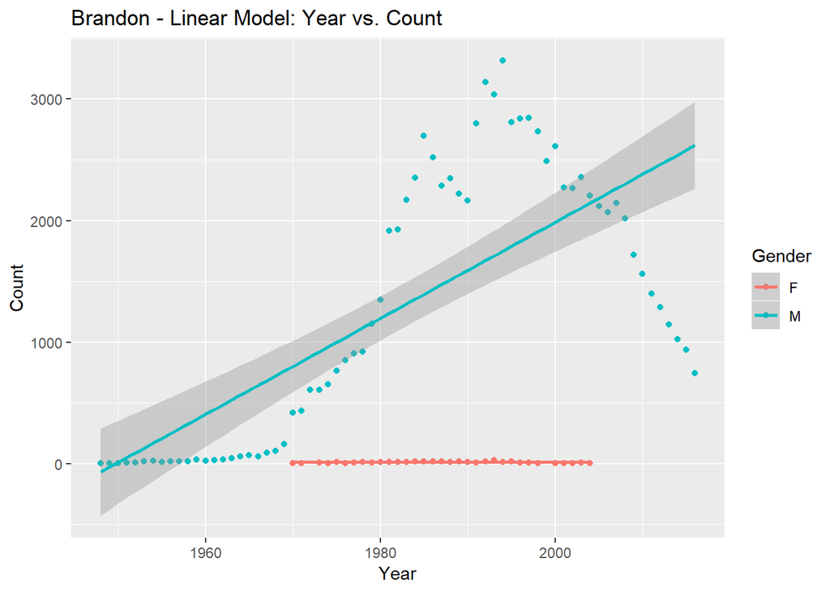

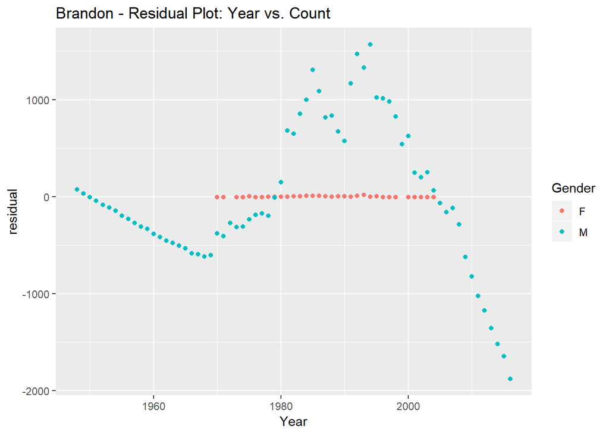

Much like with the linear models concerning Jennifers born in California across time, looking at the linear models against the scatterplots for male and female baby Brandons across time in California, and their respective residual plots, its obvious at once that the linear model is an awful fit for the male Brandons.

The name was pretty low in popularity until 1970 when it experienced a pretty steady increase until it peaked in 1994 (though there was a dip between 1985 to 1990), and it experienced a pretty steady decrease in popularity since then.

# Jennifers and Brandons: 1999 and Beyond

My friends, Brandon and Jennifer are born in 1999, so I am also curious how their names popularity changed developed after they were born.

```
##
## Call:
## lm(formula = Count ~ Year * Gender, data = jennifers_99)
##
## Residuals:
##     Min      1Q  Median      3Q     Max
## -235.74 -122.94   -0.25   95.76  388.77
##
## Coefficients:
##                Estimate Std. Error t value Pr(>|t|)
## (Intercept)   2.840e+05  1.656e+04  17.148 1.35e-12 ***
## Year         -1.409e+02  8.251e+00 -17.083 1.44e-12 ***
## GenderM      -2.806e+05  1.633e+05  -1.718    0.103
## Year:GenderM  1.392e+02  8.164e+01   1.706    0.105
## ---
## Signif. codes:  0 '***' 0.001 '**' 0.01 '*' 0.05 '.' 0.1 ' ' 1
##
## Residual standard error: 181.6 on 18 degrees of freedom
## Multiple R-squared:  0.9577, Adjusted R-squared:  0.9506
## F-statistic: 135.8 on 3 and 18 DF,  p-value: 1.505e-12
```

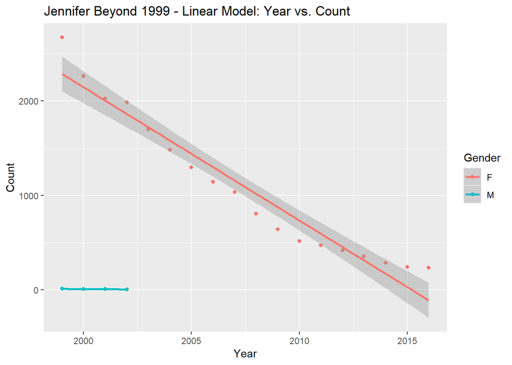

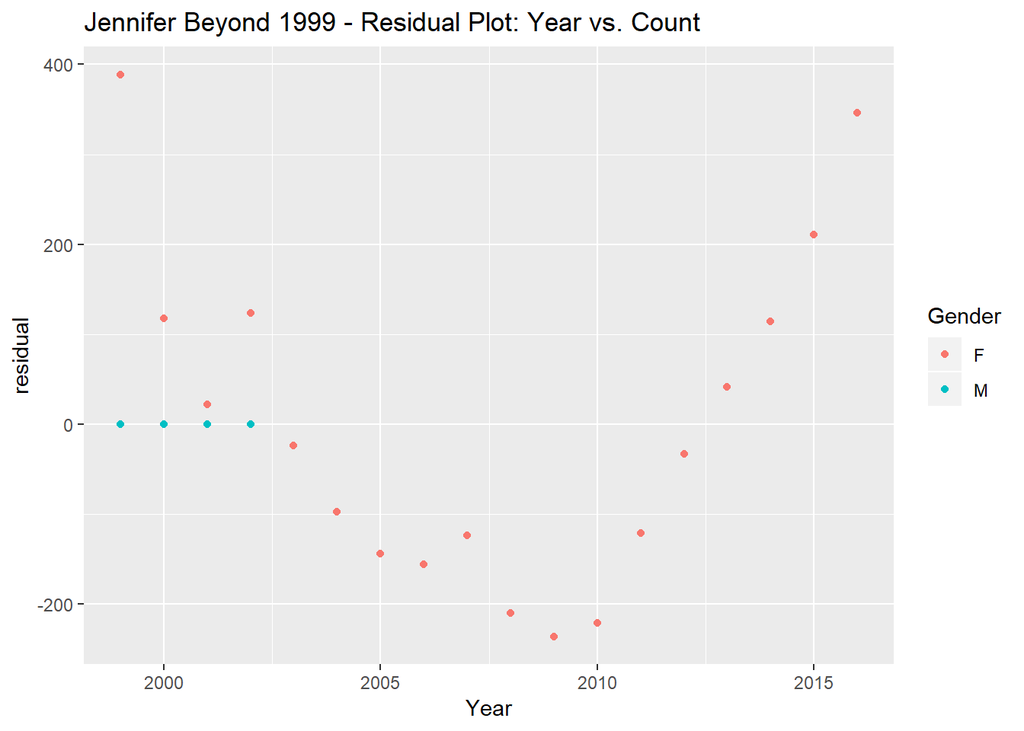

In the case of both genders, there is downward slope in popularity for the name Jennifer, though in the case of men, the slope is basically 0. For females, the slope was about -141. The last recorded instance of a male Jennifer is in 2002. For female Jennifer’s, while the linear model looks to be a decent fit, there is definitely a pattern in the residual plot, which implies that a linear model is not the best fit for this model.

```
##
## Call:
## lm(formula = Count ~ Year * Gender, data = brandons_99)
##
## Residuals:
##     Min      1Q  Median      3Q     Max
## -216.24  -68.65   -0.10   47.88  295.11
##
## Coefficients:
##               Estimate Std. Error t value Pr(>|t|)
## (Intercept)    -194.00   84743.99  -0.002   0.9982
## Year              0.10      42.33   0.002   0.9981
## GenderM      214570.41   85618.84   2.506   0.0215 *
## Year:GenderM   -105.99      42.76  -2.479   0.0227 *
## ---
## Signif. codes:  0 '***' 0.001 '**' 0.01 '*' 0.05 '.' 0.1 ' ' 1
##
## Residual standard error: 133.9 on 19 degrees of freedom
## Multiple R-squared:  0.9814, Adjusted R-squared:  0.9785
## F-statistic:   335 on 3 and 19 DF,  p-value: < 2.2e-16
```

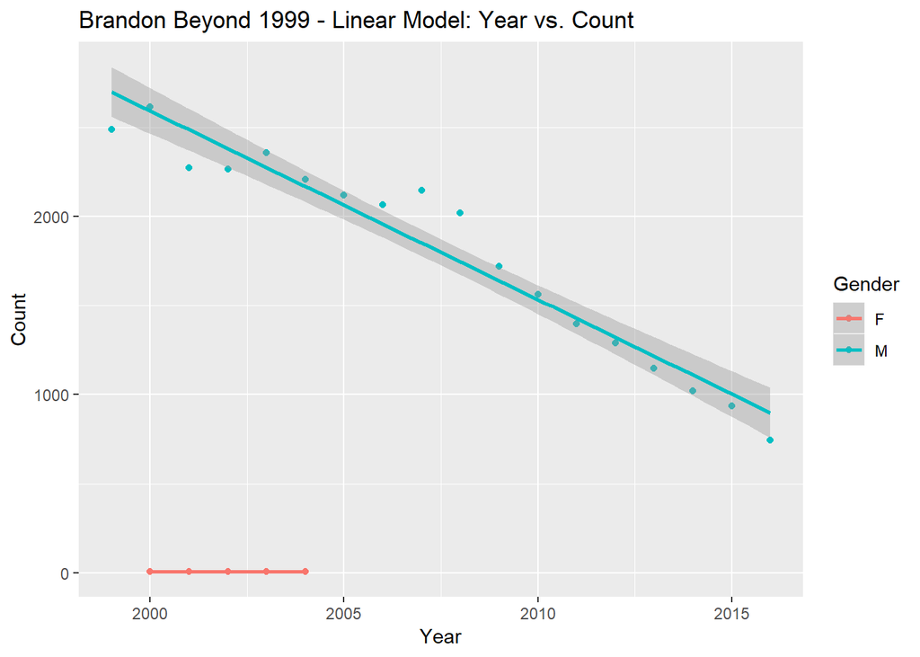

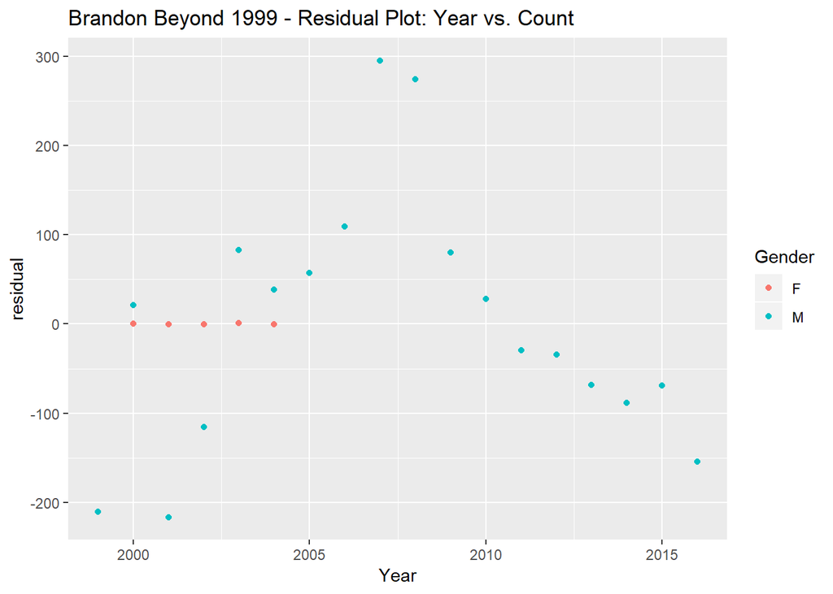